# Binary Classification Model for [Project Name] Using R version 12

### 3.c) Feature Selection

```r
# Not applicable for this iteration of the project
# Sample Code for finding collinear features (Block #1 of 2)

# Using the correlations calculated previously, we try to find attributes that are highly correlated.
# highlyCorrelated <- findCorrelation(correlations, cutoff=0.85)
# print(highlyCorrelated)
# cat('Number of attributes found to be highly correlated:',length(highlyCorrelated))
```

```r
# Sample Code for finding collinear features (Block #2 of 2)

# Removing the highly correlated attributes from the training and validation dataframes
# Xy_train <- Xy_train[, -highlyCorrelated]
# Xy_test <- Xy_test[, -highlyCorrelated]
```

```r
# Not applicable for this iteration of the project
# Sample code for performing Attribute Importance Ranking (Block #1 of 3)

# Feature Importance with Gradient Boosting Classifier
# startTimeModule <- proc.time()
# set.seed(seedNum)
# library(gbm)
# model_fs <- train(targetVar~., data=Xy_train, method="gbm", preProcess="scale", trControl=control, verbose=F)
# rankedImportance <- varImp(model_fs, scale=FALSE)
# print(rankedImportance)
# plot(rankedImportance)
```

```r
# Sample code for performing Attribute Importance Ranking (Block #2 of 3)

# Set the importance threshold and calculate the list of attributes that don't contribute to the importance threshold
# maxThreshold <- 0.99
# rankedAttributes <- rankedImportance$importance
# rankedAttributes <- rankedAttributes[order(-rankedAttributes$Overall),,drop=FALSE]
# totalWeight <- sum(rankedAttributes)
# i <- 1
# accumWeight <- 0
# exit_now <- FALSE
# while ((i <= totAttr) & !exit_now) {
#   accumWeight = accumWeight + rankedAttributes[i,]
#   if ((accumWeight/totalWeight) >= maxThreshold) {
#     exit_now <- TRUE
#   } else {
#     i <- i + 1
#   }
# }
# lowImportance <- rankedAttributes[(i+1):(totAttr),,drop=FALSE]
# lowAttributes <- rownames(lowImportance)
# cat('Number of attributes contributed to the importance threshold:',i,"\n")
# cat('Number of attributes found to be of low importance:',length(lowAttributes))
```

```r
# Sample code for performing Attribute Importance Ranking (Block #3 of 3)

# Removing the unselected attributes from the training and validation dataframes
# Xy_train <- Xy_train[, !(names(Xy_train) %in% lowAttributes)]
# Xy_test <- Xy_test[, !(names(Xy_test) %in% lowAttributes)]
```

```r
# Not applicable for this iteration of the project
# Sample code for performing Recursive Feature Elimination (Block #1 of 3)

# Perform Recursive Feature Elimination using Random Forest
# startTimeModule <- proc.time()
# set.seed(seedNum)
# X_rfe <- Xy_train[,1:totAttr]
# y_rfe <- Xy_train[,totCol]
# normalization <- preProcess(X_rfe)
# X_rfe <- predict(normalization, X_rfe)
# X_rfe <- as.data.frame(X_rfe)
# rfeCTRL <- rfeControl(functions=rfFuncs, method="cv", number=10, repeats=1, verbose=FALSE, returnResamp="all")
# optimalVars <- 50
# subsets <- c(2:optimalVars)
# rfeProfile <- rfe(X_rfe, y_rfe, sizes=subsets, rfeControl=rfeCTRL)
# print(rfeProfile)
# plot(rfeProfile, type=c("g", "o"))
```

```r
# Sample code for performing Recursive Feature Elimination (Block #2 of 3)

# Perfrom the Recursive Feature Elimination (RFE) technique
# numberRFEVars <- length(predictors(rfeProfile))
# if (numberRFEVars <= optimalVars) {
#   rfeAttributes <- predictors(rfeProfile)
# } else {
#   newProfile <- update(rfeProfile, x=X_rfe, y=y_rfe, size=optimalVars)
#   rfeAttributes <- newProfile$bestVar
# }
# cat('Number of attributes selected from the RFE algorithm:',length(rfeAttributes),'\n')
# print(rfeAttributes)
```

```r
# Sample code for performing Recursive Feature Elimination (Block #3 of 3)

# Removing the unselected attributes from the training and validation dataframes
# rfeAttributes <- c(rfeAttributes,"targetVar")
# Xy_train <- Xy_train[, (names(Xy_train) %in% rfeAttributes)]
# Xy_test <- Xy_test[, (names(Xy_test) %in% rfeAttributes)]
```

### 3.d) Display the Final Datasets for Model-Building

```r
# We finalize the training and testing datasets for the modeling activities
dim(Xy_train)
```

```
## [1] 157  61
```

```r
dim(Xy_test)
```

```
## [1] 51 61
```

```r
if (notifyStatus) email_notify(paste("Data Cleaning and Transformation completed!",date()))
```

```r
proc.time()-startTimeScript
```

```
##    user  system elapsed
##   18.18    7.36   26.37
```

## 4. Model and Evaluate Algorithms

After the data-prep, we next work on finding a workable model by evaluating a subset of machine learning algorithms that are good at exploiting the structure of the training. The typical evaluation tasks include:

- Defining test options such as cross validation and the evaluation metric to use.
- Spot checking a suite of linear and nonlinear machine learning algorithms.
- Comparing the estimated accuracy of algorithms.

For this project, we will evaluate one linear, one non-linear, and three ensemble algorithms:

Linear Algorithm: Logistic Regression

Non-Linear Algorithm: Decision Trees (CART)

Ensemble Algorithms: Bagged CART, Random Forest, and Gradient Boosting

The random number seed is reset before each run to ensure that the evaluation of each algorithm is performed using the same data splits. It ensures the results are directly comparable.

### 4.a) Generate models using linear algorithms

```r
startModeling <- proc.time()
```

```r
# Logistic Regression (Classification)
if (notifyStatus) email_notify(paste("Logistic Regression modeling has begun!",date()))
startTimeModule <- proc.time()
set.seed(seedNum)
fit.glm <- train(targetVar~., data=Xy_train, method="glm", metric=metricTarget, trControl=control)
print(fit.glm)
```

```
## Generalized Linear Model
##
## 157 samples
##  60 predictor
##   2 classes: 'M', 'R'
##
## No pre-processing
## Resampling: Cross-Validated (10 fold, repeated 1 times)
## Summary of sample sizes: 141, 142, 141, 142, 141, 142, ...
## Resampling results:
##
##   Accuracy   Kappa
##   0.6938235  0.3878228
```

```r
proc.time()-startTimeModule
```

```
##    user  system elapsed
##    0.87    0.06    0.98
```

```r
if (notifyStatus) email_notify(paste("Logistic Regression modeling completed!",date()))
```

### 4.b) Generate models using nonlinear algorithms

```r
# Decision Tree - CART (Regression/Classification)
if (notifyStatus) email_notify(paste("Decision Tree modeling has begun!",date()))
startTimeModule <- proc.time()
set.seed(seedNum)
fit.cart <- train(targetVar~., data=Xy_train, method="rpart", metric=metricTarget, trControl=control)
print(fit.cart)
```

```
## CART
##
## 157 samples
##  60 predictor
##   2 classes: 'M', 'R'
##
## No pre-processing
## Resampling: Cross-Validated (10 fold, repeated 1 times)
## Summary of sample sizes: 141, 142, 141, 142, 141, 142, ...
## Resampling results across tuning parameters:
##
##   cp          Accuracy   Kappa
##   0.04109589  0.7022059  0.4002768
##   0.07534247  0.7205392  0.4338938
##   0.52054795  0.5913725  0.1316708
##
## Accuracy was used to select the optimal model using the largest value.
## The final value used for the model was cp = 0.07534247.
```

```r
proc.time()-startTimeModule
```

```
##    user  system elapsed
##    0.90    0.03    0.93
```

```r
if (notifyStatus) email_notify(paste("Decision Tree modeling completed!",date()))
```

### 4.c) Generate models using ensemble algorithms

In this section, we will explore the use and tuning of ensemble algorithms to see whether we can improve the results.

```r
# Bagged CART (Regression/Classification)
if (notifyStatus) email_notify(paste("Bagged CART modeling has begun!",date()))
startTimeModule <- proc.time()
set.seed(seedNum)
fit.bagcart <- train(targetVar~., data=Xy_train, method="treebag", metric=metricTarget, trControl=control)
print(fit.bagcart)
```

```
## Bagged CART
##
## 157 samples
##  60 predictor
##   2 classes: 'M', 'R'
##
## No pre-processing
## Resampling: Cross-Validated (10 fold, repeated 1 times)
## Summary of sample sizes: 141, 142, 141, 142, 141, 142, ...
## Resampling results:
##
##   Accuracy   Kappa
##   0.7839216  0.5589413
```

```r
proc.time()-startTimeModule
```

```
##    user  system elapsed
##    4.13    0.01    4.22
```

```r
if (notifyStatus) email_notify(paste("Bagged CART modeling completed!",date()))
```

```r
# Random Forest (Regression/Classification)
if (notifyStatus) email_notify(paste("Random Forest modeling has begun!",date()))
startTimeModule <- proc.time()
set.seed(seedNum)
fit.rf <- train(targetVar~., data=Xy_train, method="rf", metric=metricTarget, trControl=control)
print(fit.rf)
```

```
## Random Forest
##
## 157 samples
##  60 predictor
##   2 classes: 'M', 'R'
##
## No pre-processing
## Resampling: Cross-Validated (10 fold, repeated 1 times)
## Summary of sample sizes: 141, 142, 141, 142, 141, 142, ...
## Resampling results across tuning parameters:
##
##   mtry  Accuracy   Kappa
##    2    0.8544363  0.7031428
##   31    0.7913725  0.5731117
##   60    0.7788725  0.5468892
##
## Accuracy was used to select the optimal model using the largest value.
## The final value used for the model was mtry = 2.
```

```r
proc.time()-startTimeModule
```

```
##    user  system elapsed
##    6.42    0.11    6.59
```

```r
if (notifyStatus) email_notify(paste("Random Forest modeling completed!",date()))
```

```r
# Gradient Boosting (Regression/Classification)
if (notifyStatus) email_notify(paste("Gradient Boosting modeling has begun!",date()))
startTimeModule <- proc.time()
set.seed(seedNum)
fit.gbm <- train(targetVar~., data=Xy_train, method="xgbTree", metric=metricTarget, trControl=control, verbose=F)
# fit.gbm <- train(targetVar~., data=Xy_train, method="gbm", metric=metricTarget, trControl=control, verbose=F)
print(fit.gbm)
```

```
## eXtreme Gradient Boosting
##
## 157 samples
##  60 predictor
##   2 classes: 'M', 'R'
##
## No pre-processing
## Resampling: Cross-Validated (10 fold, repeated 1 times)
## Summary of sample sizes: 141, 142, 141, 142, 141, 142, ...
## Resampling results across tuning parameters:
##
##   eta  max_depth  colsample_bytree  subsample  nrounds  Accuracy
##   0.3  1          0.6               0.50        50      0.8219363
##   0.3  1          0.6               0.50       100      0.8048039
##   0.3  1          0.6               0.50       150      0.8051716
##   0.3  1          0.6               0.75        50      0.7910049
##   0.3  1          0.6               0.75       100      0.8035539
##   0.3  1          0.6               0.75       150      0.8289706
##   0.3  1          0.6               1.00        50      0.7922059
##   0.3  1          0.6               1.00       100      0.8113725
##   0.3  1          0.6               1.00       150      0.8180392
##   0.3  1          0.8               0.50        50      0.7973039
##   0.3  1          0.8               0.50       100      0.8031863
##   0.3  1          0.8               0.50       150      0.8336520
##   0.3  1          0.8               0.75        50      0.7859559
##   0.3  1          0.8               0.75       100      0.8051225
##   0.3  1          0.8               0.75       150      0.8110049
##   0.3  1          0.8               1.00        50      0.8047059
##   0.3  1          0.8               1.00       100      0.7988725
##   0.3  1          0.8               1.00       150      0.8055392
##   0.3  2          0.6               0.50        50      0.7977206
##   0.3  2          0.6               0.50       100      0.8117892
##   0.3  2          0.6               0.50       150      0.8114216
##   0.3  2          0.6               0.75        50      0.8356373
##   0.3  2          0.6               0.75       100      0.8485539
##   0.3  2          0.6               0.75       150      0.8426716
##   0.3  2          0.6               1.00        50      0.8305392
##   0.3  2          0.6               1.00       100      0.8117892
##   0.3  2          0.6               1.00       150      0.8301716
##   0.3  2          0.8               0.50        50      0.7914216
```

[output cut: 182 more lines]

```
##   0.6559023
##   0.5931329
##   0.6579919
##   0.6707298
##   0.6177683
##   0.6562386
##   0.6549793
##
## Tuning parameter 'gamma' was held constant at a value of 0
##
## Tuning parameter 'min_child_weight' was held constant at a value of 1
## Accuracy was used to select the optimal model using the largest value.
## The final values used for the model were nrounds = 100, max_depth = 2,
##  eta = 0.4, gamma = 0, colsample_bytree = 0.6, min_child_weight = 1
##  and subsample = 1.
```

```r
proc.time()-startTimeModule
```

```
##    user  system elapsed
##   96.83   52.08  112.09
```

```r
if (notifyStatus) email_notify(paste("Gradient Boosting modeling completed!",date()))
```

### 4.d) Compare baseline algorithms

```r
results <- resamples(list(LR=fit.glm, CART=fit.cart, BagCART=fit.bagcart, RF=fit.rf, GBM=fit.gbm))
summary(results)
```

```
##
## Call:
## summary.resamples(object = results)
##
## Models: LR, CART, BagCART, RF, GBM
## Number of resamples: 10
##
## Accuracy
##              Min.   1st Qu.    Median      Mean   3rd Qu.   Max. NA's
## LR      0.5882353 0.6354167 0.6666667 0.6938235 0.7343750 0.9375    0
## CART    0.5625000 0.6519608 0.6770833 0.7205392 0.8000000 1.0000    0
## BagCART 0.5625000 0.7127451 0.7666667 0.7839216 0.8531250 1.0000    0
## RF      0.7500000 0.8031250 0.8180147 0.8544363 0.9187500 1.0000    0
## GBM     0.6875000 0.8166667 0.8750000 0.8618382 0.9364583 1.0000    0
##
## Kappa
##               Min.   1st Qu.    Median      Mean   3rd Qu.      Max. NA's
## LR      0.15602837 0.2772349 0.3360752 0.3878228 0.4687500 0.8709677    0
## CART    0.06666667 0.2967317 0.3614130 0.4338938 0.6033107 1.0000000    0
## BagCART 0.09677419 0.4115087 0.5377271 0.5589413 0.7053571 1.0000000    0
## RF      0.47540984 0.6045532 0.6341783 0.7031428 0.8361486 1.0000000    0
## GBM     0.35483871 0.6383399 0.7438525 0.7197331 0.8700400 1.0000000    0
```

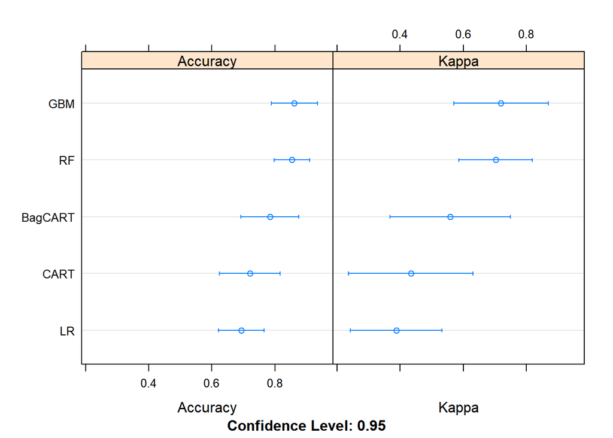

```r
dotplot(results)
```

```r
cat('The average accuracy from all models is:',
    mean(c(results$values$`LR~Accuracy`,results$values$`CART~Accuracy`,results$values$`BagCART~Accuracy`,results$values$`RF~Accuracy`,results$values$`GBM~Accuracy`)),'\n')
```

```
## The average accuracy from all models is: 0.7829118
```

```r
cat('Total training time for all models:',proc.time()-startModeling)
```

```
## Total training time for all models: 109.55 52.37 125.33 NA NA
```

## 5. Improve Accuracy or Results

After we achieve a short list of machine learning algorithms with good level of accuracy, we can leverage ways to improve the accuracy of the models.

### 5.a) Algorithm Tuning

Finally, we will tune the best-performing algorithms from each group further and see whether we can get more accuracy out of them.

```r
# Tuning algorithm #1 - Random Forest
if (notifyStatus) email_notify(paste("Algorithm #1 tuning has begun!",date()))
startTimeModule <- proc.time()
set.seed(seedNum)
grid <- expand.grid(mtry=c(2,15,30,45,60))
fit.final1 <- train(targetVar~., data=Xy_train, method="rf", metric=metricTarget, trControl=control)
print(fit.final1)
```

```
## Random Forest
##
## 157 samples
##  60 predictor
##   2 classes: 'M', 'R'
##
## No pre-processing
## Resampling: Cross-Validated (10 fold, repeated 1 times)
## Summary of sample sizes: 141, 142, 141, 142, 141, 142, ...
## Resampling results across tuning parameters:
##
##   mtry  Accuracy   Kappa
##    2    0.8544363  0.7031428
##   31    0.7913725  0.5731117
##   60    0.7788725  0.5468892
##
## Accuracy was used to select the optimal model using the largest value.
## The final value used for the model was mtry = 2.
```

```r
proc.time()-startTimeModule
```

```
##    user  system elapsed
##    6.54    0.11    6.66
```

```r
if (notifyStatus) email_notify(paste("Algorithm #1 tuning completed!",date()))
```

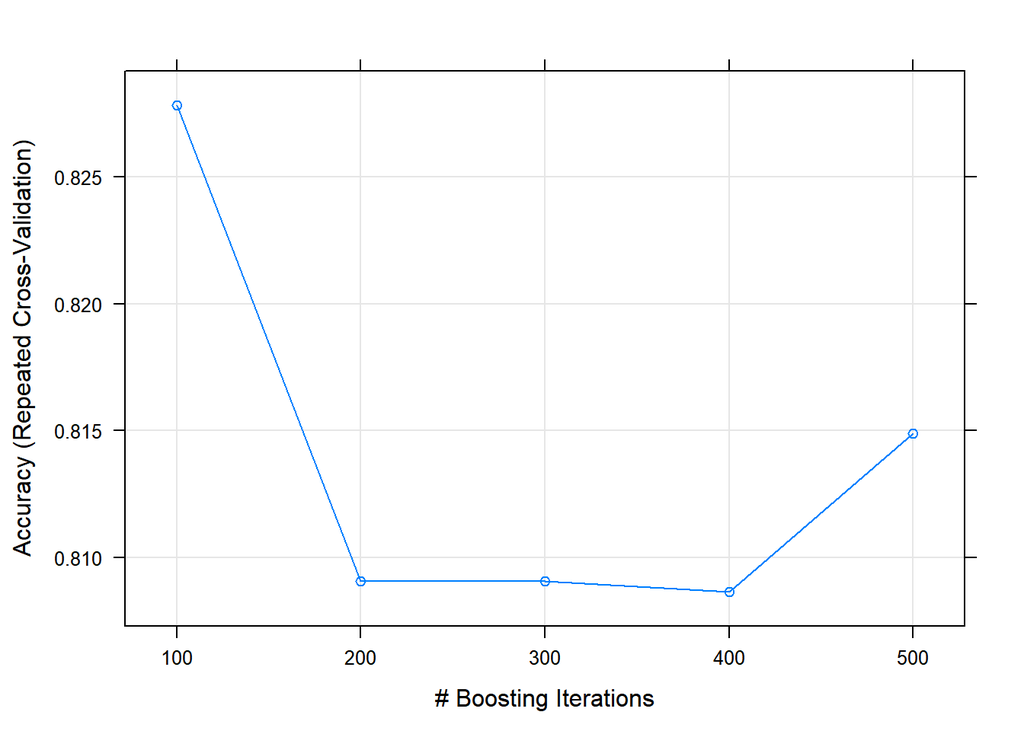

```r
# Tuning algorithm #2 - Gradient Boosting
if (notifyStatus) email_notify(paste("Algorithm #2 tuning has begun!",date()))
startTimeModule <- proc.time()
set.seed(seedNum)
grid <- expand.grid(nrounds=c(100,200,300,400,500), max_depth=3, eta=0.4, gamma=0, colsample_bytree=0.6, min_child_weight=1, subsample=0.5)
fit.final2 <- train(targetVar~., data=Xy_train, method="xgbTree", metric=metricTarget, tuneGrid=grid, trControl=control, verbose=F)
plot(fit.final2)
```

```r
print(fit.final2)
```

[output not shown]

```r
proc.time()-startTimeModule
```

```
##    user  system elapsed
##    7.04    4.21    8.87
```

```r
if (notifyStatus) email_notify(paste("Algorithm #2 tuning completed!",date()))
```

### 5.d) Compare Algorithms After Tuning

```r
results <- resamples(list(RF=fit.final1, GBM=fit.final2))
summary(results)
```

```
##
## Call:
## summary.resamples(object = results)
##
## Models: RF, GBM
## Number of resamples: 10
##
## Accuracy
##      Min.  1st Qu.    Median      Mean   3rd Qu. Max. NA's
## RF  0.750 0.803125 0.8180147 0.8544363 0.9187500    1    0
## GBM 0.625 0.762500 0.8000000 0.8278186 0.9205882    1    0
##
## Kappa
##          Min.   1st Qu.    Median      Mean   3rd Qu. Max. NA's
## RF  0.4754098 0.6045532 0.6341783 0.7031428 0.8361486    1    0
## GBM 0.2131148 0.5217890 0.6016451 0.6464008 0.8405833    1    0
```

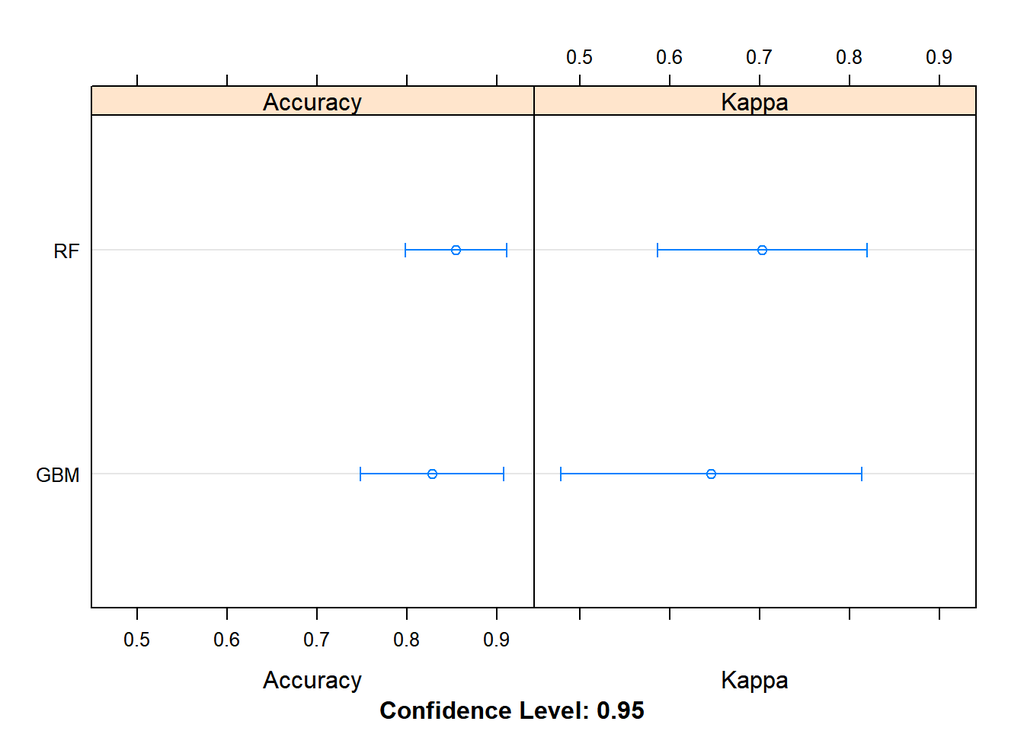

```r
dotplot(results)
```

## 6. Finalize Model and Present Results

Once we have narrow down to a model that we believe can make accurate predictions on unseen data, we are ready to finalize it. Finalizing a model may involve sub-tasks such as:

- Using an optimal model tuned to make predictions on unseen data.
- Creating a standalone model using the tuned parameters
- Saving an optimal model to file for later use.

```r
if (notifyStatus) email_notify(paste("Model Validation and Final Model Creation has begun!",date()))
```

### 6.a) Predictions on validation dataset

```r
predictions <- predict(fit.final1, newdata=Xy_test)
confusionMatrix(predictions, y_test)
```

```
## Confusion Matrix and Statistics
##
##           Reference
## Prediction  M  R
##          M 23  6
##          R  4 18
##
##                Accuracy : 0.8039
##                  95% CI : (0.6688, 0.9018)
##     No Information Rate : 0.5294
##     P-Value [Acc > NIR] : 4.341e-05
##
##                   Kappa : 0.6047
##
##  Mcnemar's Test P-Value : 0.7518
##
##             Sensitivity : 0.8519
##             Specificity : 0.7500
##          Pos Pred Value : 0.7931
##          Neg Pred Value : 0.8182
##              Prevalence : 0.5294
##          Detection Rate : 0.4510
##    Detection Prevalence : 0.5686
##       Balanced Accuracy : 0.8009
##
##        'Positive' Class : M
##
```

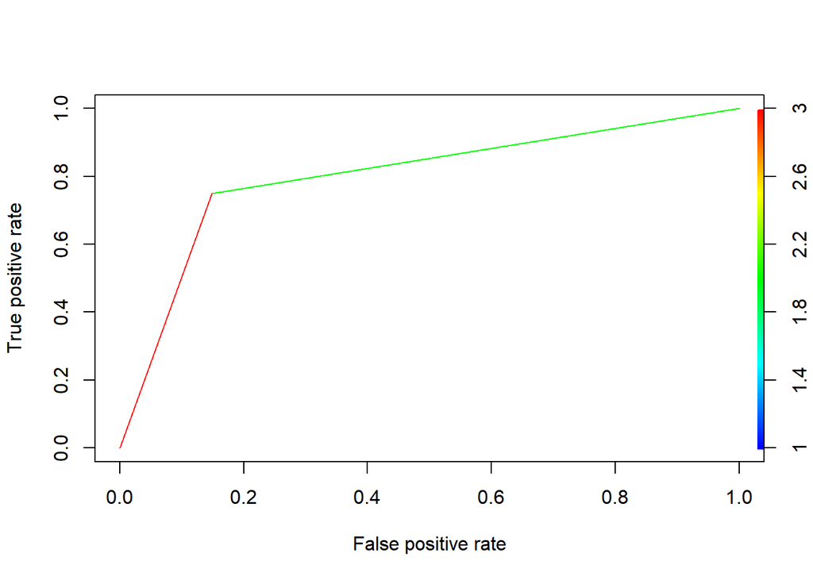

```r
pred <- prediction(as.numeric(predictions), as.numeric(y_test))
perf <- performance(pred, measure = "tpr", x.measure = "fpr")
plot(perf, colorize=TRUE)
```

```r
auc <- performance(pred, measure = "auc")
auc <- auc@y.values[[1]]
cat('The Area Under the Curve (AUC) value is:', auc)
```

```
## The Area Under the Curve (AUC) value is: 0.8009259
```

```r
predictions <- predict(fit.final2, newdata=Xy_test)
confusionMatrix(predictions, y_test)
```

```
## Confusion Matrix and Statistics
##
##           Reference
## Prediction  M  R
##          M 22  3
##          R  5 21
##
##                Accuracy : 0.8431
##                  95% CI : (0.7141, 0.9298)
##     No Information Rate : 0.5294
##     P-Value [Acc > NIR] : 2.534e-06
##
##                   Kappa : 0.6866
##
##  Mcnemar's Test P-Value : 0.7237
##
##             Sensitivity : 0.8148
##             Specificity : 0.8750
##          Pos Pred Value : 0.8800
##          Neg Pred Value : 0.8077
##              Prevalence : 0.5294
##          Detection Rate : 0.4314
##    Detection Prevalence : 0.4902
##       Balanced Accuracy : 0.8449
##
##        'Positive' Class : M
##
```

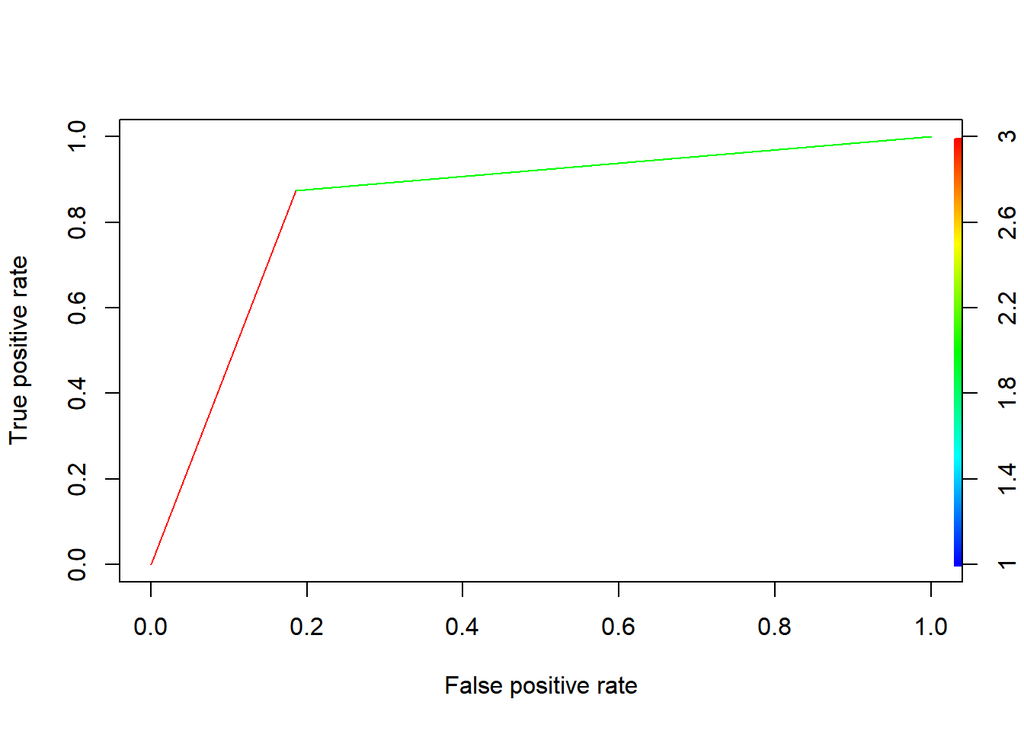

```r
pred <- prediction(as.numeric(predictions), as.numeric(y_test))
perf <- performance(pred, measure = "tpr", x.measure = "fpr")
plot(perf, colorize=TRUE)
```

```r
auc <- performance(pred, measure = "auc")
auc <- auc@y.values[[1]]
cat('The Area Under the Curve (AUC) value is:', auc)
```

```
## The Area Under the Curve (AUC) value is: 0.8449074
```

### 6.b) Create standalone model on entire training dataset

```r
startTimeModule <- proc.time()
set.seed(seedNum)

# Combining datasets to form a complete dataset that will be used to train the final model
Xy_complete <- rbind(Xy_train, Xy_test)

# library(randomForest)
# finalModel <- randomForest(targetVar~., Xy_complete, mtry=2, na.action=na.omit)
# summary(finalModel)
proc.time()-startTimeModule
```

```
##    user  system elapsed
##    0.02    0.00    0.01
```

### 6.c) Save model for later use

```r
#saveRDS(finalModel, "./finalModel_BinaryClass.rds")
```

```r
if (notifyStatus) email_notify(paste("Model Validation and Final Model Creation Completed!",date()))
```

```r
proc.time()-startTimeScript
```

```
##    user  system elapsed
##  142.34   64.42  168.68
```